# Country Analysis - Italy

## Data cleaning and formatting

We define a function to get the raw data from the corresponding url and retruning it as a dataframe.  
This function allows us to get the latest updates.

Import the latest reports from the Presidenza del Consiglio dei Ministri - Dipartimento della Protezione Civile.  
There are four datasets:

1. da_national: National data (time series).
2. da_region: Regional data (time series).
3. da_daily_region: Latest daily data on regional level.
4. da_province: Province data.

Date of the latest data to be gathered is yesterday to ensure the data is available as the files are updated daily at midnight.  
We use the date variable "ieri" to build the urls dynamically. The date format used in the Italian repository differs from the one used by the CSSE at Johns Hopkins University, this is why we need to build it.

We rename the columns to translate them to English.

| timestamp | state | hospitalized with symptoms | intensive care | total hospitalized | self-isolation | total currently positive | variation of total positive | new positive | recovered | fatalities | total positive | total tested | note_it | note_en |
| --- | --- | --- | --- | --- | --- | --- | --- | --- | --- | --- | --- | --- | --- | --- |
| 2020-02-24T18:00:00 | ITA | 101 | 26 | 127 | 94 | 221 | 0 | 221 | 1 | 7 | 229 | 4324 | nan | nan |
| 2020-02-25T18:00:00 | ITA | 114 | 35 | 150 | 162 | 311 | 90 | 93 | 1 | 10 | 322 | 8623 | nan | nan |

| date | state | regional code | region | lat | long | hospitalized with symptoms | intensive care | total hospitalized | self-isolation | total currently positive | variation of total positive | new positive | recovered | fatalities | total positive | total tested | note_it | note_en |
| --- | --- | --- | --- | --- | --- | --- | --- | --- | --- | --- | --- | --- | --- | --- | --- | --- | --- | --- |
| 2020-03-31T17:00:00 | ITA | 2 | Valle d'Aosta | 45.737503 | 7.320149 | 91 | 26 | 117 | 435 | 552 | 34 | 44 | 20 | 56 | 628 | 1582 | nan | nan |
| 2020-03-31T17:00:00 | ITA | 5 | Veneto | 45.434905 | 12.338452 | 1680 | 356 | 2036 | 5814 | 7850 | 286 | 431 | 828 | 477 | 9155 | 106238 | nan | nan |

| date | state | regional code | region | lat | long | hospitalized with symptoms | intensive care | total hospitalized | self-isolation | total currently positive | variation of total positive | new positive | recovered | fatalities | total positive | total tested | note_it | note_en |
| --- | --- | --- | --- | --- | --- | --- | --- | --- | --- | --- | --- | --- | --- | --- | --- | --- | --- | --- |
| 2020-03-31T17:00:00 | ITA | 13 | Abruzzo | 42.351222 | 13.398438 | 335 | 73 | 408 | 783 | 1191 | 22 | 56 | 95 | 115 | 1401 | 8758 | nan | nan |
| 2020-03-31T17:00:00 | ITA | 17 | Basilicata | 40.639471 | 15.805148 | 37 | 17 | 54 | 162 | 216 | 8 | 12 | 3 | 7 | 226 | 2043 | nan | nan |

## Time trends on national level

```
<function matplotlib.pyplot.show(*args, **kw)>
```

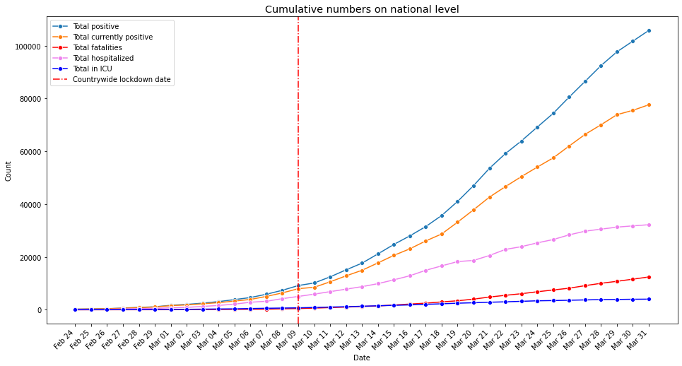

Active cases keep growing rapidly on national level. As they seem to follow the trends from [China and Korea](https://nbviewer.jupyter.org/github/kwulffert/covid-19-analysis/blob/master/Covid-19%20Analysis.ipynb), we could infere that this behaviour is expected until at least one month since the countrywide lockdown started.

## Country numbers in a nutshell

| total tested | total positive | total currently positive | recovered | self-isolation | total hospitalized | intensive care | fatalities | death rate [%] |
| --- | --- | --- | --- | --- | --- | --- | --- | --- |
| 506968 | 105792 | 77635 | 15729 | 45420 | 32215 | 4023 | 12428 | 11.747580 |

#### From all tested population we have the following figures in terms of percentage:

| total positive | total currently positive | recovered | self-isolation | total hospitalized | intensive care | fatalities |
| --- | --- | --- | --- | --- | --- | --- |
| 20.870000 | 15.310000 | 3.100000 | 8.960000 | 6.350000 | 0.790000 | 2.450000 |

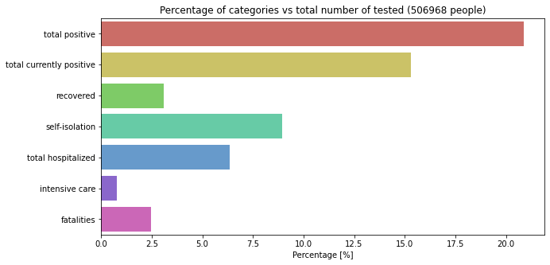

## Analysis on regional level

[interactive chart not shown]

Summary data per country is shown if you point on each country's block.

### Top four regions with most active cases

Lombardia is the region with the bigest share of cases of those currently active.  
As the outbreak hit Lombardia first, the number of fatalities and recovered cases are higher, explaining the lower number of currently cases in comparison to the total of cases. As of 30.03 the number of active cases in the region is slowing down.  
In the other regions, the outbreak started more recently, therefore the actual positive and total positive in those regions are very close to each other and the curve of active cases keeps growing.

| region | total tested | total positive | total currently positive | percentage of active [%] | percentage of total positive [%] |
| --- | --- | --- | --- | --- | --- |
| Lombardia | 114640 | 43208 | 25124 | 32.360000 | 40.840000 |
| Emilia-Romagna | 54532 | 14074 | 10953 | 14.110000 | 13.300000 |
| Piemonte | 27658 | 9301 | 8082 | 10.410000 | 8.790000 |
| Veneto | 106238 | 9155 | 7850 | 10.110000 | 8.650000 |

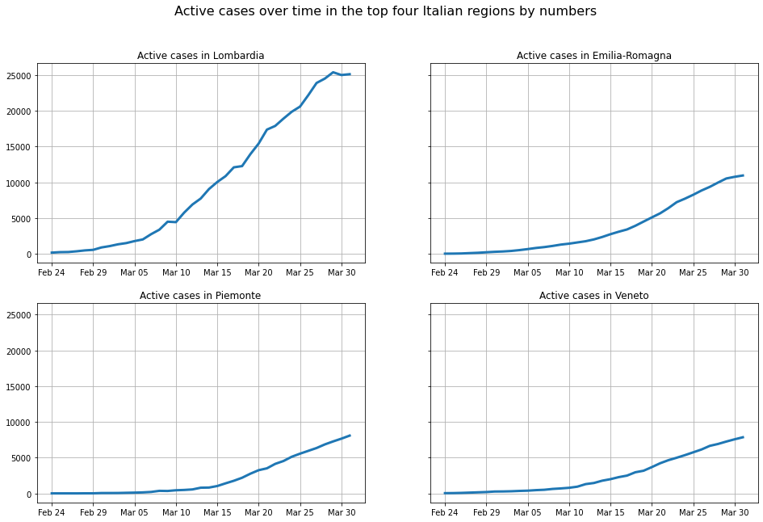

## Time trend in Lombardia

```
<function matplotlib.pyplot.show(*args, **kw)>
```

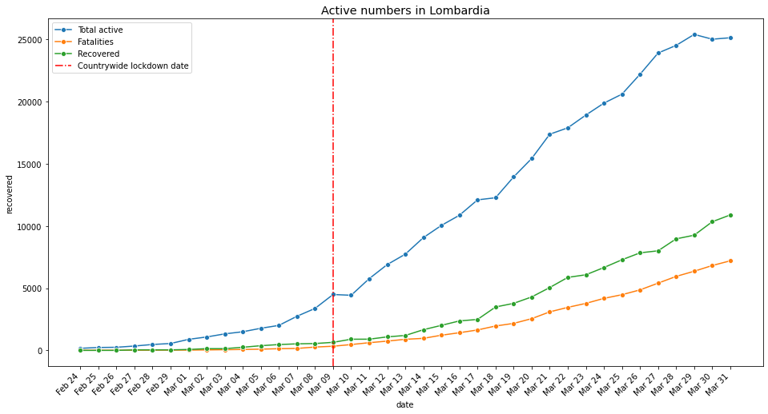

As of 31.03, the peak of active cases is registered on 29.03.  
Looking at the trends in [China and Korea](https://nbviewer.jupyter.org/github/kwulffert/covid-19-analysis/blob/master/Covid-19%20Analysis.ipynb), for the former the trend flattened for about five days before starting to go down;  
for the latter, there were 5 days of oscillations after the peak value until the curve started to go down steadily.